# 第二周作业参考答案

# 第一题

### 参考一

2018200222-查王皓天

## Problem1

第二周课上补充材料cs229linalg.pdf中第9页，

证明$trABC=trBCA=trCAB$

## Assumption

不妨设矩阵A$\in R^ { m\times n}$，矩阵B$\in R^ { n\times p}$，矩阵C$\in R^ { p\times m}$

## Solution

$\begin{eqnarray*} tr(ABC) &=& \sum_{i=1}^{m} [(AB)C]_{ii}\quad \quad 先把AB看成整体\\ &=& \sum_{i=1}^{m}\sum_{j=1}^{p}(AB)_{ij}C_{ji}\quad 把矩阵ABC的ii项拆开\\ &=& \sum_{i=1}^{m}\sum_{j=1}^{p}(\sum_{k=1}^{n}A_{ik}B_{kj})C_{ji}\quad \quad 把矩阵AB的ij项拆开\\ &=& \sum_{k=1}^{n}\sum_{i=1}^{m}\sum_{j=1}^{p}B_{kj}C_{ji}A_{ik}\quad \quad 交换求和顺序\\ &=& \sum_{k=1}^{n}\sum_{i=1}^{m}(BC)_{ki}A_{ik}\quad \quad 重新组合\\ &=& \sum_{k=1}^{n}[(BC)A]_{ii}\\ &=& tr(BCA) \end{eqnarray*} $

同理，

$\begin{eqnarray*} tr(ABC) &=& \sum_{i=1}^{m} [(AB)C]_{ii}\\ &=& \sum_{i=1}^{m}\sum_{j=1}^{p}(AB)_{ij}C_{ji}\\ &=& \sum_{i=1}^{m}\sum_{j=1}^{p}(\sum_{k=1}^{n}A_{ik}B_{kj})C_{ji}\\ &=& \sum_{j=1}^{p}\sum_{k=1}^{n}\sum_{i=1}^{m}C_{ji}A_{ik}B_{kj}\\ &=& \sum_{j=1}^{p}\sum_{k=1}^{n}(CA)_{jk}B_{kj}\\ &=& \sum_{j=1}^{p}[(CA)B]_{ii}\\ &=& tr(CAB) \end{eqnarray*} $

综上可得，$tr(ABC)=tr(BCA)=tr(CAB)$

### 参考二

2019202105-李佳瞳

## 补充材料九页，证明：trABC=trBCA=trCAB

### 不妨假设：

$$ A_{m*n}= \left\{ \begin{matrix} a_{11} & a_{12} & \cdots & a_{1n}\\ a_{21} & a_{22} & \cdots & a_{2n} \\ \vdots & \vdots & \ddots & \vdots \\ a_{m1} & a_{m2} & \cdots & a_{mn} \end{matrix} \right\} $$$$ B_{n*p}= \left\{ \begin{matrix} b_{11} & b_{12} & \cdots & b_{1p}\\ b_{21} & b_{22} & \cdots & b_{2p} \\ \vdots & \vdots & \ddots & \vdots \\ b_{n1} & b_{n2} & \cdots & b_{np} \end{matrix} \right\} $$$$ C_{p*m}= \left\{ \begin{matrix} c_{11} & c_{12} & \cdots & c_{1m}\\ c_{21} & c_{22} & \cdots & c_{2m} \\ \vdots & \vdots & \ddots & \vdots \\ c_{p1} & c_{p2} & \cdots & c_{pm} \end{matrix} \right\} $$

则有： $$ ABC_{m*m}= \left\{ \begin{matrix} \sum_{i=1}^{n}\sum_{j=1}^{p} a_{1i}b_{ij}c_{j1} & \sum_{i=1}^{n}\sum_{j=1}^{p} a_{1i}b_{ij}c_{j2} & \cdots & \sum_{i=1}^{n}\sum_{j=1}^{p} a_{1i}b_{ij}c_{jm}\\ \sum_{i=1}^{n}\sum_{j=1}^{p} a_{2i}b_{ij}c_{j1} & \sum_{i=1}^{n}\sum_{j=1}^{p} a_{2i}b_{ij}c_{j2} & \cdots & \sum_{i=1}^{n}\sum_{j=1}^{p} a_{2i}b_{ij}c_{jm}\\ \vdots & \vdots & \ddots & \vdots \\ \sum_{i=1}^{n}\sum_{j=1}^{p} a_{mi}b_{ij}c_{j1} & \sum_{i=1}^{n}\sum_{j=1}^{p} a_{mi}b_{ij}c_{j2} & \cdots & \sum_{i=1}^{n}\sum_{j=1}^{p} a_{mi}b_{ij}c_{jm} \end{matrix} \right\} $$

$$ trABC=\sum_{k=1}^{m}(ABC)_{kk}= \sum_{k=1}^{m}\sum_{i=1}^{n}\sum_{j=1}^{p} a_{ki}b_{ij}c_{jk} $$

同理： $$ trBCA=\sum_{k=1}^{m}(BCA)_{ii}= \sum_{i=1}^{n}\sum_{j=1}^{p}\sum_{k=1}^{m} b_{ij}c_{jk}a_{ki} $$ $$ trCAB=\sum_{k=1}^{m}(ABC)_{jj}= \sum_{j=1}^{p}\sum_{k=1}^{m}\sum_{i=1}^{n} c_{jk}a_{ki}b_{ij} $$

综上有： $$ trABC=trBCA=trCAB $$

### 参考三

2019202091-徐克丰

## 证明

先证明$tr AB= tr BA$: 设矩阵$A$为$n\times{m}$阶，$B$为$m\times{n}$阶矩阵,则有： \begin{equation} trBA=\sum_{j=1}^{m}d_{jj}=\sum_{j=1}^{m}\sum_{k=1}^{n}b_{jk}a_{kj}=\sum_{k=1}^{n}\sum_{j=1}^{m}a_{kj}b_{jk}=\sum_{i=1}^{n}\sum_{k=1}^{m}a_{ik}b_{ki}=\sum_{i=1}^{n}c_{ii}=trAB \end{equation} 如果扩展到三个矩阵，设矩阵$A,B,C$之间相乘是有意义的，并且矩阵之积为方阵，由上面证明的$trAB=trBA$可知： \begin{equation} trABC=tr(AB)C=trC(AB)=trCAB\\ trBCA=trB(CA)=tr(CA)B=trCAB\\ \end{equation} 于是得证：$$trABC=trBCA=trCAB$$

# 第二题

### 参考一

2019202091-徐克丰

## 解答

1.表示上述二元方程组为

\begin{equation} \left [ \begin{array}{cc} 1 & 1 \\ 2 & -1 \end{array}\right ] \left [ \begin{array}{c} x \\ y \end{array}\right ]= \left [ \begin{array}{c} 27 \\ 0 \end{array}\right] \end{equation}

矩阵$A$的逆为 \begin{equation} A^{-1}= \frac{1}{|A|}A^* = -\frac{1}{3} \left [ \begin{array}{cc} -1 & -1\\ -2 & 1 \end{array}\right]= \left [ \begin{array}{ccc} \frac{1}{3} & \frac {1}{3} \\ \frac{2}{3} & -\frac {1}{3} \end{array}\right] \end{equation}

求解$X=A^{-1}b$的结果 \begin{equation} X= \left [ \begin{array}{cc} \frac{1}{3} & \frac {1}{3} \\ \frac{2}{3} & -\frac {1}{3} \end{array}\right] \left [ \begin{array}{c} 27\\ 0\\ \end{array}\right]= \left[ \begin{array}{c} 9\\ 18 \end{array}\right ] \end{equation}

该方程组对应的增广矩阵为 \begin{equation} %开始数学环境 \left[ \begin{array}{ccc} 1 & 1 & 27 \\ 2& -1 & 0 \end{array} \right ] \end{equation}

矩阵$A$的迹为 $$Tr(A)=1-1=0$$

矩阵$A$的F范数为 \begin{equation} ||A||_F = \sqrt{1^2+1^2+2^2+(-1)^2}=\sqrt{7} \end{equation}

2.将矩阵表示成对称矩阵+反对称矩阵的形式为 \begin{equation} A=\frac{1}{2}(A+A^T)+\frac{1}{2}(A-A^T)= \left[ \begin{array}{cc} 1 & \frac{3}{2} \\ \frac{3}{2} & -1 \end{array}\right ]+ \left[ \begin{array}{cc} 0 & -\frac{1}{2} \\ \frac{1}{2} & 0 \end{array}\right ] \end{equation}

3.计算矩阵$A$的行列式为 $$|A|=1\times{(-1)}-2\times{1}=-3$$ 下面是行列式几何意义的绘制代码与图像

## code

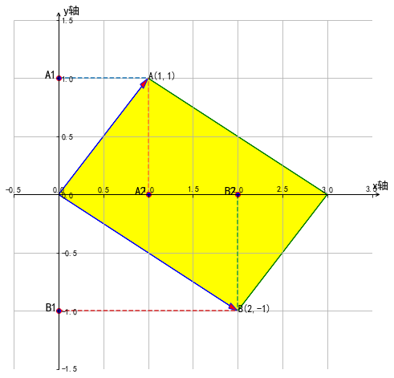

```python
#绘制行列式的几何意义——平行四边形的面积
import numpy as np
import matplotlib.pyplot as plt  #引入python的库
import matplotlib.animation as animation
#创建画布并引入axisartist工具
import mpl_toolkits.axisartist as axisartist

plt.rcParams['font.sans-serif']=['SimHei'] # 用来正常显示中文标签
plt.rcParams['axes.unicode_minus']=False # 用来正常显示负号

fig=plt.figure(figsize=(8,8)) #创建画布
ax=axisartist.Subplot(fig,111) #设置一个绘图区对象
fig.add_axes(ax)  #将绘图区对象添加到画布中
#隐藏原有坐标轴
ax.axis[:].set_visible(False)
#添加新的坐标轴，并给坐标轴加上箭头
ax.axis["x"] = ax.new_floating_axis(0,0)#添加新的坐标轴
ax.axis["x"].set_axisline_style("->", size = 1.0)#给x坐标轴加上箭头
ax.axis["y"] = ax.new_floating_axis(1,0)
ax.axis["y"].set_axisline_style("->", size = 1.0)
#设置刻度显示方向
ax.axis["x"].set_axis_direction("top")
ax.axis["y"].set_axis_direction("right")
#在图中绘制四边形并填充颜色
x=[0,1,3,2]
y=[0,1,0,-1]
plt.fill(x,y,color='yellow')  #绘制封闭区域
#plt.plot(x0,y0,color='r',markerfacecolor='blue',marker='o')  #添加交点标记
plt.text(1,1,'A(1,1)', fontsize=12)
plt.text(2,-1,'B(2,-1)',fontsize=12)
#添加箭头，构建向量和平行四边形
plt.arrow(0,0,1,1,length_includes_head = True,head_width = 0.05,head_length =0.1,fc = 'r',ec = 'b')
plt.arrow(0,0,2,-1,length_includes_head = True,head_width = 0.05,head_length =0.1,fc = 'r',ec = 'b')
plt.arrow(1,1,2,-1,length_includes_head = True,head_width =0,head_length =0,fc = 'r',ec = 'g')
plt.arrow(2,-1,1,1,length_includes_head = True,head_width =0,head_length =0,fc = 'r',ec = 'g')
plt.axis([-0.5,3.5,-1.5,1.5])  #设置坐标轴的范围
plt.grid()  #添加网格
plt.text(3.5,0.05,'x轴',fontsize=14)
plt.text(0.05,1.55,'y轴',fontsize=14)
#绘制投影到坐标轴上的虚线
x1=[[0,1],[1,1],[2,2],[0,2]]
y1=[[1,1],[0,1],[0,-1],[-1,-1]]
for i in range(len(x)):
    plt.plot(x1[i],y1[i],linestyle='--')
#绘制投影的坐标点
x2=[0,0,1,2]
y2=[1,-1,0,0]
let2=['A1','B1','A2','B2']
for i in range(len(x)):
    plt.plot(x2[i],y2[i],color='r',markerfacecolor='blue',marker='o')  #添加交点标记
    plt.text(x2[i]-0.15,y2[i],let2[i],fontsize=15)
plt.show()
```

补充：关于行列式的几何意义表示中，行列式为负值的问题。

行列式等于平行四边形的有向面积。以逆时针为正方向，以原点(0,0)为不动点，将点A(1,1)【行列式第一行的坐标】绕着原点逆时针转向到点B(2,-1)，若此过程中扫过的面积在平行四边形内则有向面积为正，否则有向面积为负。

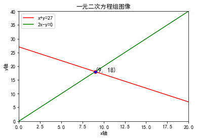

```python
#两条直线及其交点绘制
import numpy as np
import matplotlib.pyplot as plt  #引入python的库
plt.rcParams['font.sans-serif']=['SimHei'] # 用来正常显示中文标签
plt.rcParams['axes.unicode_minus']=False # 用来正常显示负号
x=np.linspace(0,20,2)       #生成0--20之间的2个数(直线两点作图)
y1=27-x     #写方程
y2=2*x
plt.plot(x,y1,color='red')
plt.plot(x,y2,color='green')  #画图
x0=9;y0=18   #同行代码需要添加分号
plt.plot(x0,y0,color='r',markerfacecolor='blue',marker='o')  #添加交点标记
plt.text(x0,y0,(x0,y0), fontsize=12)
plt.legend(['x+y=27','2x-y=0'],loc='upper left')
plt.title('一元二次方程组图像')  #设置标题，坐标轴名称以及坐标轴范围
plt.xlabel('x轴')
plt.ylabel('y轴')
plt.axis([0,20,0,40])
plt.show()  #展示坐标轴
```

# 参考二

2019202450-陈诺

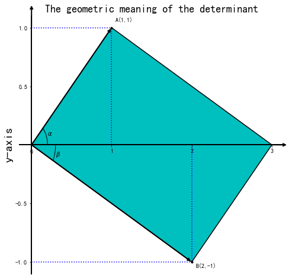

```python
import math
import numpy as np
import matplotlib
matplotlib.use('Qt5Agg')#必须显式指明matplotlib的后端
import matplotlib.pyplot as plt
import matplotlib.patches as patches

fig=plt.figure(figsize=(8,8))
ax = fig.gca()

#不显示右侧和上侧的框线
ax.spines['right'].set_visible(False)
ax.spines['top'].set_visible(False)

#设置左边直线(y轴)的属性
#坐标轴颜色
ax.spines['left'].set_color('black')
#坐标轴宽度
ax.spines['left'].set_linewidth(2)
#刻度在轴线左侧
ax.yaxis.set_ticks_position('left')
#刻度的位置
ax.yaxis.set_ticks([-1,-0.5,0.5,1])
#刻度显示为红色
ax.tick_params(axis='y',colors='black')
#设置左侧轴线位置
#参数必须是元组(type,amount)
#('data',0)表示数据为0的位置
ax.spines['left'].set_position(('data',0))
#使用annotate在y轴顶端创建箭头
ax.annotate('',(0,1),xytext=(0,1.2),arrowprops={'arrowstyle':'<-','color':'black','linewidth':2})
#设置底部直线(x轴)的属性
ax.spines['bottom'].set_color('black')
ax.spines['bottom'].set_linewidth(2)
ax.spines['bottom'].set_position(('data',0))
ax.xaxis.set_ticks([0,1,2,3])
ax.annotate('',(3,0),xytext=(3.2,0),arrowprops={'arrowstyle':'<-','color':'black','linewidth':2})
ax.tick_params(axis='x',colors='black')

# Parallelogram
x = [0,1,3,2]
y = [0,1,0,-1]
#ax.add_patch(patches.Polygon(xy=list(zip(x,y)),linewidth='1.5',fill=False))
ax.add_patch(patches.Polygon(xy=list(zip(x,y)),linewidth='1.5',edgecolor='black',facecolor="c"))

#标角
a1 = np.linspace(0,math.atan(1),600)
x1 = np.cos(a1)*0.2
y1 = np.sin(a1)*0.2
ax.plot(x1,y1,color='black',linewidth='1.0')

a2 = np.linspace(0,math.atan(-0.5),600)
x2 = np.cos(a2)*0.3
y2 = np.sin(a2)*0.3
ax.plot(x2,y2,color='black',linewidth='1.0')

#标注点
ax.plot([1,1],[0,1],linestyle=':',color='blue')
ax.plot([0,1],[1,1],linestyle=':',color='blue')
ax.annotate('',(0,0),xytext=(1,1),arrowprops={'arrowstyle':'<-','color':'black','linewidth':2})
ax.plot(1,1,'.',color='black')
plt.text(1.05,1.05,'A(1,1)')
ax.plot([2,2],[0,-1],linestyle=':',color='blue')
ax.plot([0,2],[-1,-1],linestyle=':',color='blue')
ax.plot(2,-1,'.',color='black')
ax.annotate('',(0,0),xytext=(2,-1),arrowprops={'arrowstyle':'<-','color':'black','linewidth':2})
plt.text(2.05,-1.05,'B(2,-1)')

#标注角的名称
plt.text(0.2,0.08, r'$\alpha$')
plt.text(0.3,-0.1,r'$\beta$')

#坐标轴和标题，以及字号
plt.ylabel('y-axis',fontsize=20)
plt.title('The geometric meaning of the determinant',fontsize=18)

plt.show()
```